# Lab 8: Feature Engineering

K Arnold & K Westra

10/23/2020

## Data

Load data from `modeldata` package.

```r
data(ames, package = "modeldata")
ames <- ames %>%
  filter(Gr_Liv_Area < 4000, Sale_Condition == "Normal") %>%
  mutate(across(where(is.integer), as.double))
```

Hold out a test set.

```r
set.seed(10) # Seed the random number generator
ames_split <- initial_split(ames, prop = 2/3) # Split our data randomly
ames_train <- training(ames_split)
ames_test <- testing(ames_split)
```

We'll use one example home from the test set.

```r
example_home <- ames_test %>% slice(1)
example_home %>% select(Gr_Liv_Area, Sale_Price)
```

```
## # A tibble: 1 x 2
##   Gr_Liv_Area Sale_Price
##         <dbl>      <dbl>
## 1        1656     215000
```

## Recipe

Here we set up the recipe:

```r
ames_recipe <-
  recipe(Sale_Price ~ Gr_Liv_Area + Latitude + Longitude, data = ames_train) %>%
  #make the scale the SAME for all of these!!!!
  step_range(Gr_Liv_Area, Latitude, Longitude, min = 0, max = 1) %>%
  prep()
ames_recipe %>% summary()
```

```
## # A tibble: 4 x 4
##   variable    type    role      source
##   <chr>       <chr>   <chr>     <chr>
## 1 Gr_Liv_Area numeric predictor original
## 2 Latitude    numeric predictor original
## 3 Longitude   numeric predictor original
## 4 Sale_Price  numeric outcome   original
```

Let's look at its output on the training data:

```r
ames_recipe %>% bake(new_data = ames_train)
```

```
## # A tibble: 1,608 x 4
##    Gr_Liv_Area Latitude Longitude Sale_Price
##          <dbl>    <dbl>     <dbl>      <dbl>
##  1       0.161    0.865     0.634     105000
##  2       0.285    0.861     0.637     172000
##  3       0.371    0.968     0.469     189900
##  4       0.364    0.966     0.469     195500
##  5       0.422    0.946     0.467     189000
##  6       0.379    0.936     0.486     175900
##  7       0.324    0.932     0.471     180400
##  8       0.289    0.920     0.506     171500
##  9       0.335    0.945     0.521     212000
## 10       0.845    0.972     0.576     538000
## # … with 1,598 more rows
```

## Workflow

`workflow` = `recipe` + `model`

```r
ames_workflow <- workflow() %>%
  add_model(linear_reg() %>% set_engine("lm")) %>%
  add_recipe(ames_recipe)
```

Workflows can `fit` and `predict`. First let's `fit` it on our training data...

```r
fitted_workflow <- fit(ames_workflow, data = ames_train)
```

Now let's see what it predicts for our example home.

```r
fitted_workflow %>% predict(example_home)
```

```
## # A tibble: 1 x 1
##     .pred
##     <dbl>
## 1 193865.
```

Let's peek inside the model.

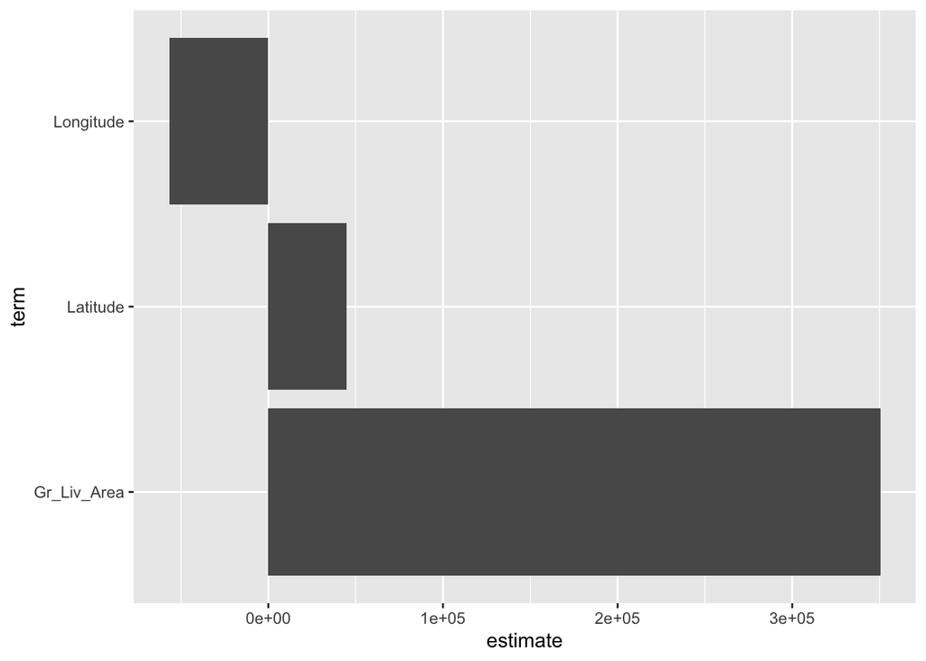

```r
fitted_workflow %>%
  tidy() %>%
  filter(term != "(Intercept)") %>%
  ggplot(aes(x = estimate, y = term)) + geom_col()
```

```r
ames_train %>% select(Gr_Liv_Area, Latitude, Longitude) %>% summary()
```

```
##   Gr_Liv_Area      Latitude       Longitude
##  Min.   : 334   Min.   :41.99   Min.   :-93.69
##  1st Qu.:1103   1st Qu.:42.02   1st Qu.:-93.66
##  Median :1432   Median :42.03   Median :-93.64
##  Mean   :1483   Mean   :42.03   Mean   :-93.64
##  3rd Qu.:1734   3rd Qu.:42.05   3rd Qu.:-93.62
##  Max.   :3820   Max.   :42.06   Max.   :-93.58
```

Because these features are on such totally different scalees, if we want a similar effect, we need a huge coefficient.

## Test the model

```r
fitted_workflow %>%
  pull_workflow_prepped_recipe() %>%
  bake(new_data = ames_test) %>% #<<
  summary()
```

```
##   Gr_Liv_Area         Latitude           Longitude          Sale_Price
##  Min.   :0.02983   Min.   :0.0001431   Min.   :0.002473   Min.   : 45000
##  1st Qu.:0.21916   1st Qu.:0.4561704   1st Qu.:0.276807   1st Qu.:130438
##  Median :0.31268   Median :0.6255804   Median :0.464684   Median :157000
##  Mean   :0.32349   Mean   :0.6145951   Mean   :0.445049   Mean   :173960
##  3rd Qu.:0.39472   3rd Qu.:0.8007264   3rd Qu.:0.619621   3rd Qu.:207500
##  Max.   :0.90620   Max.   :0.9994147   Max.   :0.806102   Max.   :615000
```

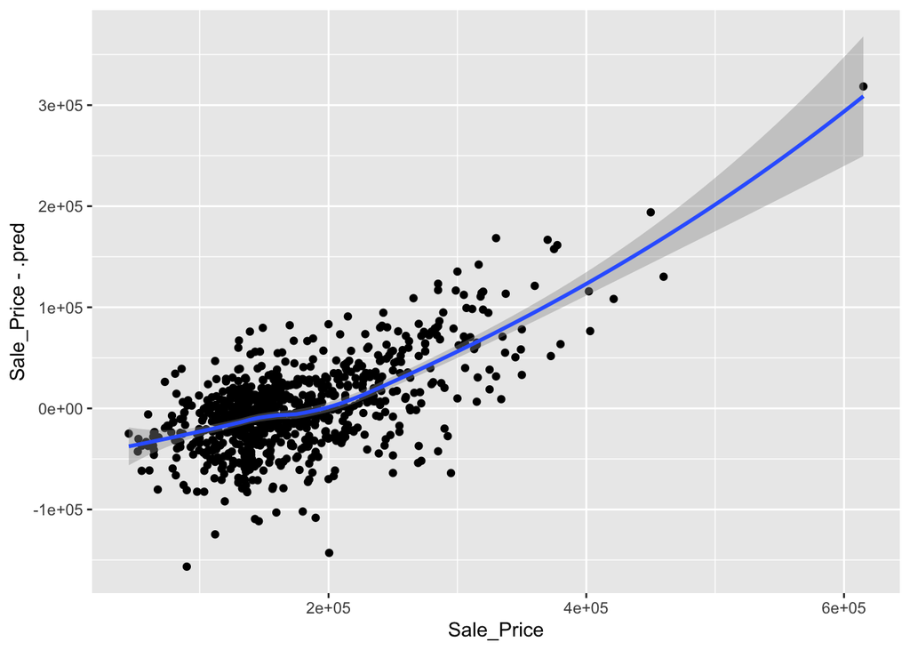

```r
fitted_workflow %>%
  predict(ames_test) %>%
  bind_cols(ames_test) %>%
  ggplot(aes(x = Sale_Price, y = Sale_Price - .pred)) + geom_point() + geom_smooth()
```

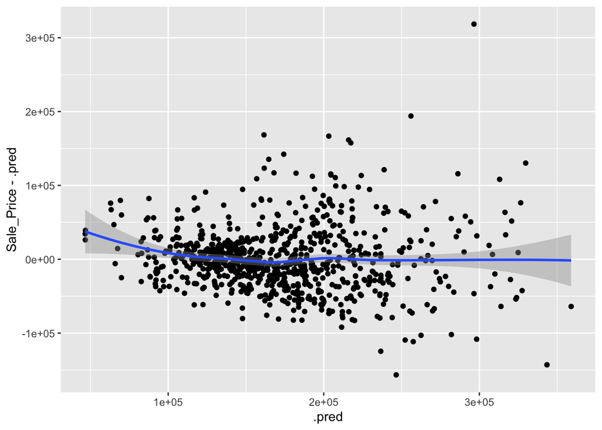

```r
fitted_workflow %>%
  predict(ames_test) %>%
  bind_cols(ames_test) %>%
  ggplot(aes(x = .pred, y = Sale_Price - .pred)) + geom_point() + geom_smooth()
```

## Conditional Logic

Do remodeled homes sell for more?  
From codebook: remodel data = construction date if no remodeling or additions.

```r
ames_train_2 <- ames_train %>%
  mutate(remodeled = case_when(
    Year_Built == Year_Remod_Add ~ "no",
    TRUE                         ~ "yes") %>%
    as_factor()
  )
```

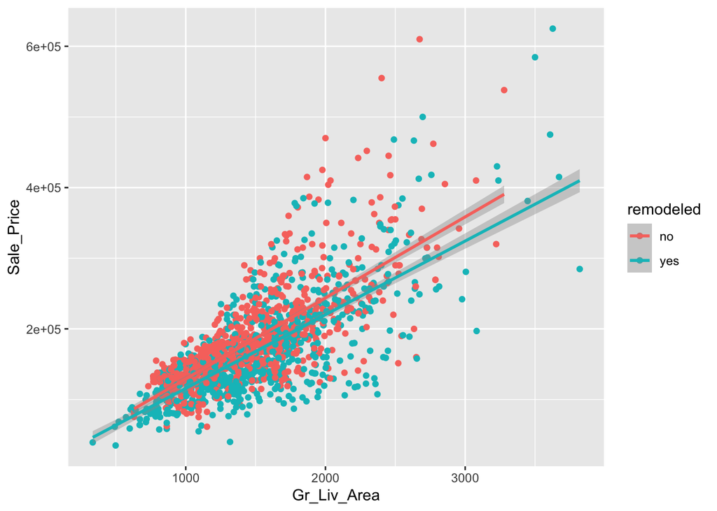

```r
ames_train_2 %>%
  ggplot(aes(x = Gr_Liv_Area, y = Sale_Price, color = remodeled)) +
  geom_point() +
  geom_smooth(method = "lm")
```

It looks like remodelled homes sell for... less? Yet correlation ≠ causation, and it might be that somethinng that caused a model also brought about price-lowering things...

#### *AS AN ASIDE:*

```r
ames_2 <- ames %>%
  mutate(remodeled = Year_Remod_Add != Year_Built)

ames_2 %>%
  group_by (remodeled) %>%
  summarize(n = n()) %>%
  mutate(proportion = n / sum(n))
```

```
## # A tibble: 2 x 3
##   remodeled     n proportion
##   <lgl>     <int>      <dbl>
## 1 FALSE      1303      0.540
## 2 TRUE       1109      0.460
```

```r
ames_2 %>%
  summarize(num_remodeled = sum(remodeled == T),
            Prop_remodeled = mean(remodeled == T))
```

```
## # A tibble: 1 x 2
##   num_remodeled Prop_remodeled
##           <int>          <dbl>
## 1          1109          0.460
```

Linear model... treating remodelled homes differently from non-remodelled.

**dummy encoding**

essentailly, we just add a term:

Sale_Price =  
intercept_other  
+ coef_remodeled * (1 if remodeled)  
+ coef_sqft * Gr_Liv_Area

(similar to what we did in the aside above!) A *conditional* intercept.

How to do it:

```r
ames_recipe_3 <-
  recipe(Sale_Price ~ Gr_Liv_Area + remodeled, data = ames_train_2) %>%
  step_dummy(remodeled) %>%
  # rescalling step:
  #step_range(all_numeric(), -all_outcomes(), min = 0, max = 1) %>%
  prep()

baked_ames_train <-
  ames_recipe_3 %>% bake(new_data = ames_train_2)

baked_ames_train %>% head(5) %>% knitr::kable(format = "html")
```

| Gr_Liv_Area | Sale_Price | remodeled_yes |
| --- | --- | --- |
| 896 | 105000 | 0 |
| 1329 | 172000 | 0 |
| 1629 | 189900 | 1 |
| 1604 | 195500 | 0 |
| 1804 | 189000 | 0 |

```r
#having a "remodeled_no" column is unnecessary -- it's just a 0 in our remodeled_yes col!
```

```r
ames_model_2 <- linear_reg() %>% set_engine("lm") %>%
  fit(Sale_Price ~ ., data = baked_ames_train)
ames_model_2 %>% tidy() %>% select(term, estimate) %>% knitr::kable()
```

| term | estimate |
| --- | --- |
| (Intercept) | 22643.4248 |
| Gr_Liv_Area | 109.1132 |
| remodeled_yes | -18424.0789 |

Sale_Price = 22643 + -18424.0789 * (1 if remodeled) + 109.1132 * Gr_Liv_Area

If remodelleed, subtract 18k from price :( otherwise, just keep going.

```r
typeof(baked_ames_train$remodeled_yes)
```

```
## [1] "double"
```

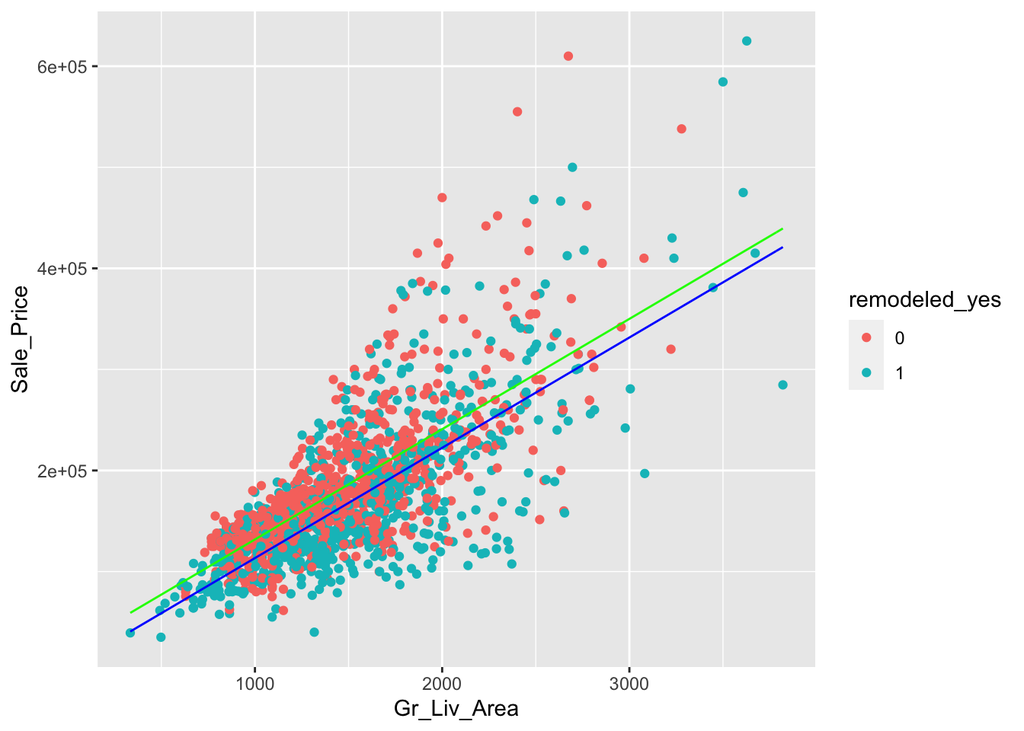

```r
baked_ames_train %>%
  mutate(remodeled_yes = as.factor(remodeled_yes)) %>%
ggplot(aes(x = Gr_Liv_Area, y = Sale_Price, color = remodeled_yes)) +
  geom_point() +
  geom_function(fun = function(x) (22643.4248 - 18424.0789) + 109.1132 * x, color = "blue") +
  geom_function(fun = function(x) 22643.4248 + 109.1132 * x, color = "green")
```

More than 2 options:

```r
ames_train %>% count(Bldg_Type) %>% knitr::kable()
```

| Bldg_Type | n |
| --- | --- |
| OneFam | 1355 |
| TwoFmCon | 37 |
| Duplex | 43 |
| Twnhs | 56 |
| TwnhsE | 117 |

```r
ames_recipe_4 <-
  recipe(Sale_Price ~ Gr_Liv_Area + Bldg_Type, data = ames_train) %>%
  step_dummy(Bldg_Type) %>%
  #step_range(all_numeric(), -all_outcomes(), min = 0, max = 1) %>%
  prep()
baked_ames_train <-
  ames_recipe_4 %>% bake(new_data = ames_train_2)
baked_ames_train %>% head(5) %>% knitr::kable(format = "html")
```

| Gr_Liv_Area | Sale_Price | Bldg_Type_TwoFmCon | Bldg_Type_Duplex | Bldg_Type_Twnhs | Bldg_Type_TwnhsE |
| --- | --- | --- | --- | --- | --- |
| 896 | 105000 | 0 | 0 | 0 | 0 |
| 1329 | 172000 | 0 | 0 | 0 | 0 |
| 1629 | 189900 | 0 | 0 | 0 | 0 |
| 1604 | 195500 | 0 | 0 | 0 | 0 |
| 1804 | 189000 | 0 | 0 | 0 | 0 |

Creates 4 columns! ^^ the first isn't included because it's built into the intercept.

Which one gets treated as base: depends on package. Statistical inferenece: which condition is being treated as baseline. (this is important to think this through... does one make more sense than the other)

> > ran into this problem w/ CSR data -- homeless was treated as the baseline to which everything else was statistically signifiant.!s

** contrasts w/ baseline!! **

**Interpret** as: diff between ____ and [baseline]

## Another kind of model: Decision Trees

[see examples](https://cs.calvin.edu/courses/data/202/ka37/slides/w09/w9d2-conditional-logic.html#16) and specific [R code and output](https://cs.calvin.edu/courses/data/202/ka37/slides/w09/w9d2-conditional-logic.html#17)

different parts of tree can look @ diff things

**TWO KINDS OF REGRESSION MODELS**

Linear Regression - To make a prediction: multiply terms by constants, sum it all up  
- Conditional logic by explicitly transforming data to invent special terms  
- Output looks like lines (or curves, if you add $x^2$ terms)

Decision Tree Regression  
- To make a prediction: follow conditional logic rules (determined automatically from data) to output a number  
- Output looks like stair-steps